# Processo Seletivo - PLURALL Soluções em Saúde Suplementar

ISMAEL BARBOZA DE OLIVERA

2026-03-24

# 1 Introdução – Análise dos Custos Assistenciais

Este relatório apresenta uma análise detalhada dos custos assistenciais, focando no padrão de utilização e na severidade dos gastos por tipo de procedimento. A base de dados compreende o período de 12 meses (dezembro de 2024 a novembro de 2025), utilizando registros de beneficiários únicos para garantir a consistência dos resultados e evitar distorções por duplicidade.

As métricas calculadas — frequência média de utilização, custo total e custo médio por procedimento — visam oferecer suporte a análises atuariais, processos de precificação e monitoramento da sustentabilidade econômico-financeira do plano.

A Tabela 1 resume as estatísticas de utilização e custos da carteira. Observa-se que os Exames apresentam a maior frequência média de utilização 21.65, seguidos pelas Consultas 4.69, consolidando-se como os procedimentos mais recorrentes. Na prática, isso indica que, em média, um beneficiário realiza cerca de 5 consultas e 22 exames ao longo de doze meses.

Sob a ótica financeira, os Exames concentram o maior impacto nos custos assistenciais, totalizando aproximadamente R$ 2.015.748,72. Esse montante representa cerca de 62.55% do custo total do período, destacando-se como o principal componente das despesas assistenciais analisadas.

**Tabela 1 - Resumo dos Custos Assistenciais por Tipo de Procedimento**

| Tipo de Procedimento | Frequência Média de Utilização | Custo Total | Custo Médio por Procedimento |
| --- | --- | --- | --- |
| Consultas | 4,6946 | R$1.207.049,20 | R$124,77 |
| Exames | 21,6522 | R$2.015.748,72 | R$45,18 |

Ao longo do período de dezembro de 2024 a novembro de 2025, observa-se que o custo assistencial acumulado mensal apresenta uma média de 268.566,49 mil. Entretanto, a série é caracterizada por uma acentuada volatilidade, com flutuações mensais que variam de aproximadamente 225.000 a mais de 325.000.

Conforme ilustrado na figura, destaca-se um movimento de forte ascensão nos meses finais de 2025, atingindo o pico da série em novembro. Além dessa tendência de alta recente, o gráfico evidencia um comportamento cíclico de vales seguidos de recuperações rápidas, sugerindo a influência de fatores sazonais ou eventos pontuais de alta frequencia em um mês no período analisado.

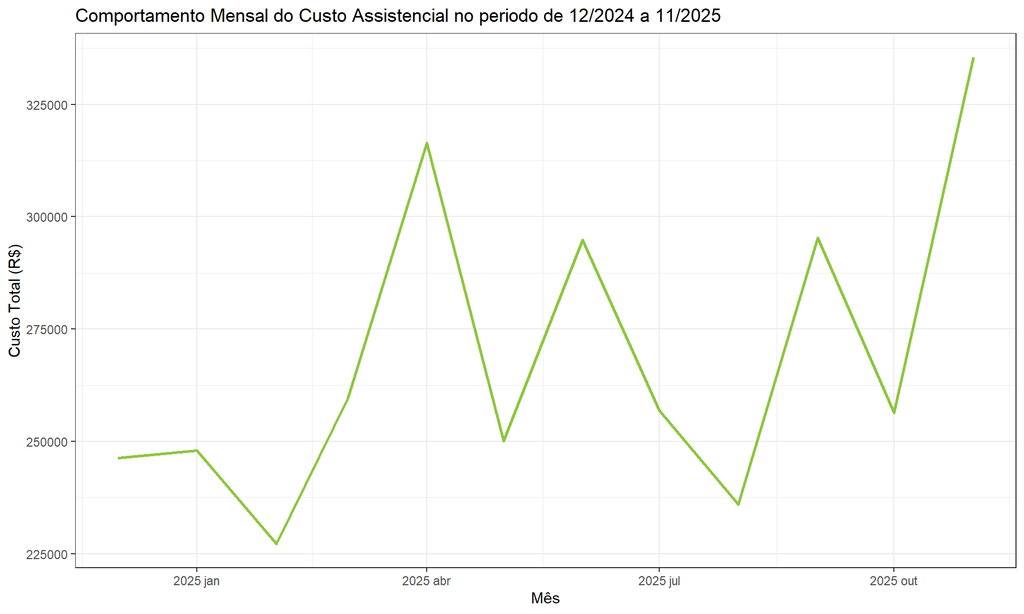

Ao analisar o comportamento dos custos assistenciais entre dezembro de 2024 e novembro de 2025, observa-se que a composição do gasto total é fortemente impactada pelo efeito volume. Conforme demonstrado na Tabela 1, embora o custo médio por procedimento das Consultas (R$ 124,77) seja mais que o dobro do custo médio dos Exames (R$ 45,18), a altíssima recorrência destes últimos inverte a predominância financeira.

Essa dinâmica fica evidente ao constatarmos que 100% dos dez maiores registros de utilização individual referem-se a exames. Esse cenário confirma que o principal direcionador de custo da operação não é a severidade (preço elevado por evento), mas sim a frequência de utilização, que atua como o principal ofensor da sinistralidade no período.

Quanto ao perfil demográfico desse grupo de alta utilização, o sexo masculino, representa aproximadamente 60% do total. A Tabela 2 detalha esses eventos, permitindo visualizar como o acúmulo de exames, ainda que individualmente mais baratos que uma consulta, consolida-se como o maior impacto financeiro para o plano de saúde.

**Tabela 2 – Top 10 Maiores Gastadores no Ano de 2025**

| ID | idade | Sexo | Tipo_Procedimento | Custo_Total | Frequencia_Absoluta |
| --- | --- | --- | --- | --- | --- |
| 65_F_238 | 65 | F | Exames | R$12.103,13 | 303 |
| 75_F_635 | 75 | F | Exames | R$8.430,24 | 98 |
| 60_M_135 | 60 | M | Exames | R$7.925,24 | 91 |
| 10_M_92 | 10 | M | Exames | R$7.217,84 | 89 |
| 79_M_715 | 79 | M | Exames | R$7.209,85 | 83 |
| 66_F_472 | 66 | F | Exames | R$6.709,55 | 64 |
| 39_F_302 | 39 | F | Exames | R$6.616,86 | 51 |
| 80_M_222 | 80 | M | Exames | R$6.225,59 | 109 |
| 81_M_744 | 81 | M | Exames | R$5.895,47 | 194 |
| 66_M_62 | 66 | M | Exames | R$5.673,02 | 32 |

# 2 Análise Demográfica - Perfil das Utilizações

Historicamente, o público feminino apresenta maior engajamento com cuidados preventivos, o que costuma resultar em uma frequência de utilização superior à do sexo masculino. Entretanto, a composição demográfica deste contrato específico apresenta um cenário distinto. Conforme detalhado na figura a seguir, dos 1830 beneficiários totais, 60.33% são do sexo masculino, enquanto o sexo oposto representa 39.67%. Tais dados evidenciam uma predominância masculino na carteira, contrariando a expectativa de maior volume de beneficiárias mulheres comumente observada no setor.

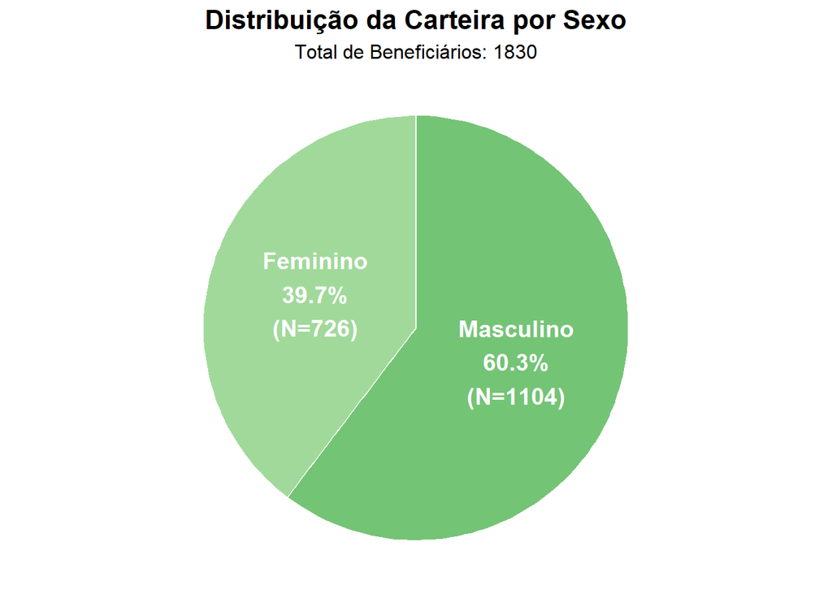

A distribuição dos custos assistenciais no período analisado revela um comportamento típico de carteiras de saúde, caracterizado por uma progressão de gastos diretamente proporcional ao envelhecimento dos beneficiários. Observa-se o fenômeno da curva de permanência e custo, em que a severidade financeira atinge seu ápice nas idades mais avançadas, especificamente na faixa de 59 anos ou mais. Este grupo isoladamente representa o maior desafio para a sustentabilidade do contrato, acumulando aproximadamente R$ 2,22 milhões em despesas. Dentro deste estrato sênior, a disparidade de gênero é acentuada: o custo associado ao sexo masculino supera o feminino em cerca de 42%, sugerindo uma concentração de eventos de alta complexidade ou o manejo de condições crônicas mais severas entre os homens.

Um achado transversal em toda a série histórica é a predominância do custo masculino sobre o feminino em todos os intervalos de idade. Embora o público feminino apresente uma participação expressiva na frequência de utilização de serviços simples, a severidade dos eventos masculinos nesta carteira é consistentemente superior. Esse cenário corrobora a hipótese de que o público masculino tende a acessar o sistema de saúde em estágios mais avançados de enfermidades, gerando custos unitários mais elevados por evento. Diante disso, a gestão da sinistralidade deve focar em estratégias de monitoramento para o público acima de 50 anos, visando antecipar diagnósticos e controlar a progressão de custos nessas faixas de alta severidade.

**Tabela 3 – Custo Assistencial por Faixa Etária e Sexo**

| Faixa Etária | Custo Sexo Feminino (R$) | Custo Sexo Masculino (R$) |
| --- | --- | --- |
| Entre 0 e 18 | R$65.026,63 | R$106.991,71 |
| Entre 19 a 23 | R$18.536,70 | R$31.575,11 |
| Entre 24 a 28 | R$18.866,01 | R$31.702,82 |
| Entre 29 a 33 | R$26.494,18 | R$32.929,67 |
| Entre 34 a 38 | R$49.758,62 | R$75.032,83 |
| Entre 39 a 43 | R$61.103,56 | R$66.934,31 |
| Entre 44 a 48 | R$71.727,76 | R$101.505,82 |
| Entre 49 a 53 | R$53.035,88 | R$56.323,70 |
| Entre 54 a 58 | R$43.146,16 | R$86.816,36 |
| 59 ou + | R$918.144,68 | R$1.307.145,41 |

Como observado anteriormente, o contrato apresenta uma predominância de beneficiários em idades mais avançadas, com uma média etária de 64.4 anos. Esse perfil demográfico implica, naturalmente, uma maior probabilidade de utilização dos serviços assistenciais, uma vez que o avanço da idade está correlacionado ao aumento da cronicidade e à maior fragilidade biológica, exigindo intervenções médicas mais frequentes e complexas.

Além da concentração na faixa sênior, nota-se que o sexo masculino é predominante na maioria das faixas etárias, e que a primeira infância (0 a 18 anos) detém o segundo maior volume de vidas da carteira. Essa distribuição configura um acentuado desequilíbrio etário: a escassez de beneficiários em faixas intermediárias (jovens adultos) compromete o princípio do mutualismo, onde os mais jovens e saudáveis auxiliam no custeio dos mais idosos. Caso essa estrutura populacional se mantenha, o contrato poderá sofrer reflexos financeiros severos, exigindo reajustes mais elevados para garantir a sustentabilidade e o equilíbrio econômico-financeiro da operação.

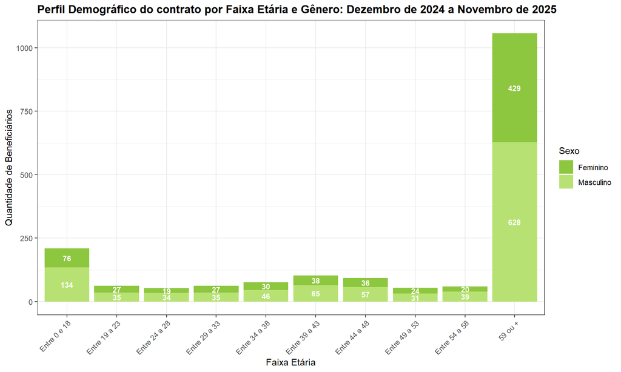

A análise da quantidade de procedimentos evidencia um padrão claro de concentração da utilização assistencial nas faixas etárias mais avançadas, com destaque absoluto para o grupo de 59 anos ou mais. Essa faixa registrou 38.328 procedimentos, correspondendo a aproximadamente 70,6% de toda a utilização do contrato, o que demonstra uma forte dependência dos serviços de saúde por parte dos beneficiários idosos.

Esse comportamento reforça o impacto do envelhecimento sobre a demanda assistencial, uma vez que o avanço da idade está diretamente associado ao aumento da necessidade de acompanhamento clínico e realização de exames diagnósticos. Observa-se, inclusive, que o volume dessa faixa etária supera, de forma expressiva, o somatório individual das demais faixas, evidenciando sua relevância estrutural na composição da sinistralidade.

De forma secundária, destaca-se a faixa de 0 a 18 anos, com 2.486 procedimentos, configurando-se como o segundo maior volume observado. Esse padrão sugere uma demanda relevante entre beneficiários jovens, possivelmente associada a atendimentos preventivos, pediatria e acompanhamento do desenvolvimento.

Nas faixas intermediárias, entre 19 e 58 anos, observa-se uma distribuição relativamente homogênea, porém com predominância consistente de exames sobre consultas. No consolidado geral, os exames totalizam 44.618 registros, enquanto as consultas somam 9.674, indicando que os exames são aproximadamente 4,6 vezes mais frequentes, o que evidencia um perfil assistencial fortemente orientado ao diagnóstico.

Por fim, os resultados reforçam que o envelhecimento da carteira não apenas eleva o volume de utilização, mas o faz de maneira altamente concentrada. Esse padrão representa um fator crítico para a sustentabilidade do contrato, exigindo estratégias de gestão de saúde e precificação atuarial que considerem o peso desproporcional das faixas etárias mais elevadas sobre o custo assistencial.

**Tabela 4 – Quantidade de Procedimentos por Faixa Etária**

| Fx_Etaria | Consultas | Exames | Total |
| --- | --- | --- | --- |
| Entre 0 e 18 | 861 | 1.625 | 2.486 |
| Entre 19 a 23 | 218 | 565 | 783 |
| Entre 24 a 28 | 184 | 739 | 923 |
| Entre 29 a 33 | 203 | 748 | 951 |
| Entre 34 a 38 | 407 | 1.708 | 2.115 |
| Entre 39 a 43 | 355 | 1.925 | 2.280 |
| Entre 44 a 48 | 493 | 2.391 | 2.884 |
| Entre 49 a 53 | 265 | 1.445 | 1.710 |
| Entre 54 a 58 | 349 | 1.483 | 1.832 |
| 59 ou + | 6.339 | 31.989 | 38.328 |
| Total | 9.674 | 44.618 | 54.292 |

A análise da frequência média de utilização por faixa etária, em conjunto com os indicadores gerais da carteira, reforça de forma consistente o impacto do envelhecimento sobre o comportamento assistencial dos beneficiários. Observa-se um crescimento progressivo da utilização conforme o avanço da idade, culminando na faixa de 59 anos ou mais, que apresenta os maiores níveis de frequência tanto em consultas (6,20) quanto, principalmente, em exames (30,94), ambos acima da média geral da carteira.

Sob a ótica financeira, observa-se uma dinâmica relevante: embora os exames apresentem maior frequência de utilização, seu custo médio por procedimento (R$ 45,18) é significativamente inferior ao das consultas (R$ 124,77). Ainda assim, devido ao elevado volume, os exames totalizam R$ 2,0 milhões em custos, superando as consultas, que somam R$ 1,2 milhão. Esse comportamento evidencia que os exames atuam como principal driver de custo agregado da carteira, não pelo valor unitário, mas pela intensidade de uso.

Ao analisar as faixas intermediárias, especialmente entre 34 e 58 anos, observa-se que a frequência de exames já supera, em diversos casos, a média geral, antecipando um padrão de utilização mais intenso antes mesmo da entrada nas faixas etárias mais avançadas. Esse fenômeno sugere um efeito de transição do risco assistencial, no qual a carteira começa a apresentar sinais de maior pressão de utilização de forma precoce, o que pode impactar negativamente a evolução futura dos custos.

Nas faixas mais jovens, embora a frequência de exames também se apresente relevante — como observado entre 0 e 18 anos (10,76) — os níveis permanecem significativamente abaixo da média geral, indicando um perfil de utilização mais controlado e, em geral, associado a práticas preventivas. Dessa forma, ainda que contribuam para o volume assistencial, esses grupos não representam, isoladamente, um fator crítico de risco financeiro.

Por fim, os resultados demonstram que o envelhecimento da carteira impacta simultaneamente a frequência de utilização e o custo agregado, especialmente por meio do aumento expressivo na realização de exames. Esse padrão reforça a necessidade de estratégias atuariais e de gestão voltadas ao controle da utilização, acompanhamento de pacientes crônicos e avaliação da pertinência dos procedimentos, uma vez que a intensificação do uso dos serviços tende a pressionar de forma significativa a sustentabilidade econômico-financeira do contrato ao longo do tempo.

**Tabela 5 – Frequência Média de Utilização por Faixa Etária**

| Fx_Etaria | Consultas | Exames |
| --- | --- | --- |
| Entre 0 e 18 | 4.20 | 10.76 |
| Entre 19 a 23 | 3.63 | 10.66 |
| Entre 24 a 28 | 3.68 | 15.08 |
| Entre 29 a 33 | 3.50 | 14.11 |
| Entre 34 a 38 | 5.65 | 24.06 |
| Entre 39 a 43 | 3.78 | 20.48 |
| Entre 44 a 48 | 5.36 | 27.48 |
| Entre 49 a 53 | 4.91 | 26.76 |
| Entre 54 a 58 | 6.02 | 25.14 |
| 59 ou + | 6.20 | 30.94 |

A distribuição espacial dos procedimentos assistenciais revela uma rede de atendimento com altíssima concentração regional, operando de forma quase exclusiva dentro de limites geográficos específicos. Em uma análise de magnitude estadual, observa-se que o estado de Minas Gerais detém 99,9% da utilização total do contrato. Essa hegemonia absoluta em território mineiro demonstra que a operação está profundamente enraizada na infraestrutura de saúde local, com uma presença meramente residual no estado de São Paulo, que responde por apenas 0,1% dos eventos registrados.

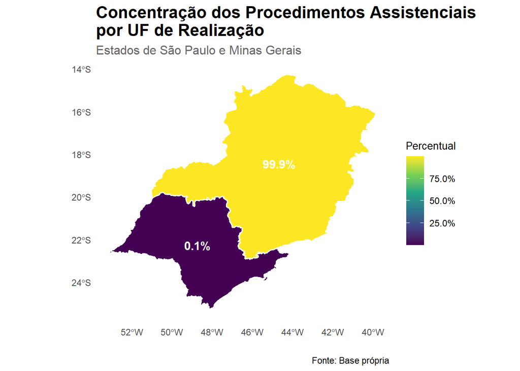

Ao refinarmos a análise para o nível municipal, a característica de centralização torna-se ainda mais evidente. O município de Viçosa consolida-se como o principal polo assistencial, absorvendo 79% de todo o volume de utilização da carteira. Esta concentração em um único município sugere que a rede credenciada local é o pilar de sustentação do plano, possivelmente devido à proximidade física do grupo de beneficiários e à disponibilidade de recursos técnicos na região.

Complementando a rede de atendimento mineira, destacam-se Belo Horizonte, com 10,5%, e Florestal, com 5,3% do volume de procedimentos. Juntos, os três primeiros municípios (Viçosa, Belo Horizonte e Florestal) são responsáveis por quase 95% da utilização assistencial. As demais localidades, como Juiz de Fora (1,4%) e Pará de Minas (1,3%), apresentam participações pulverizadas, reforçando que, embora o plano possua abrangência para atendimentos em outros centros, o fluxo assistencial é massivamente direcionado para polos específicos de Minas Gerais.

[figure not shown]

# 3 Conclusão